# **Project Summary**

This case study was completed to fulfill the Capstone Project requirement of the Google Data Analytics Professional Certificate.

### Background:

Bellabeat is a wellness company which manufactures a health and fitness tracking app which collects and displays data from several smart devices.

### Business Task:

Analyze and leverage trends in consumer usage of smart devices to inform Bellabeat’s marketing strategy.

### Data Sources:

Data is not available from Bellabeat devices, so proxy data from the [FitBit Fitness Tracker Data](https://www.kaggle.com/datasets/arashnic/fitbit?resource=download) dataset is used for this analysis. No metadata is available for the variables included in this dataset.

This dataset consists of thirty-five FitBit users’ sleep, weight, and physical activity data obtained from FitBit devices between March 12th, 2016 and May 12th, 2016.

- Fitness data includes number of steps, calories burned, heart rate, metabolic equivalent of task (MET), intensity, distance, and time.
- Weight data includes weight kg/lbs, fat, and BMI.
- Sleep data includes minutes asleep and time in bed.

For certain variables, data is aggregated differently across different files. **This analysis focuses on activity data at the activity-session level (e.g., number of steps/calories burned per activity session) and daily weight and sleep data.**

### Data Cleaning and Transformation, and Analysis:

Data Cleaning and Validation Checks were performed to identify and correct out-of-range, inconsistent, missing, and duplicated data.

Data Transformation The following key metrics were computed and used in analysis:

1. Number of participants who used each of the three tracking features (activity, sleep, and weight) each day of data collection.
2. Average daily percentage of time spent sedentary and engaging in activities at each intensity level.
3. Median daily minutes asleep, in bed, and awake in bed for each participant.

Additional metrics were computed and documented in the Data Transformation section of this project, but did not reveal insights relevant to the business task.

### Summary of Results:

Data Analysis revealed three key actionable insights:

1. Consumers most frequently used smart devices to track their activity levels. Sleep tracking was the second most frequently used feature. Few consumers used their smart devices to track weight.

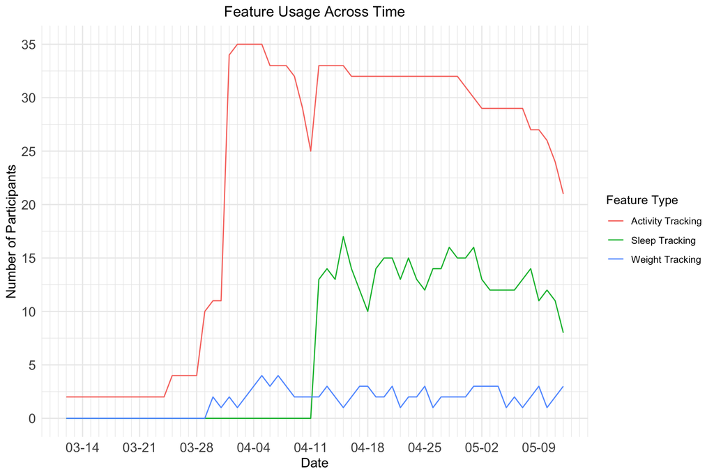

2. Consumers were typically sedentary for about 82% (~17 hours) of the day and engaged in light intensity activity for about 15% (~3 hours) of their day. Consumers only engaged in fairly or very intense activity for about 1-2% of the day, respectively (~14 - 20 minutes).

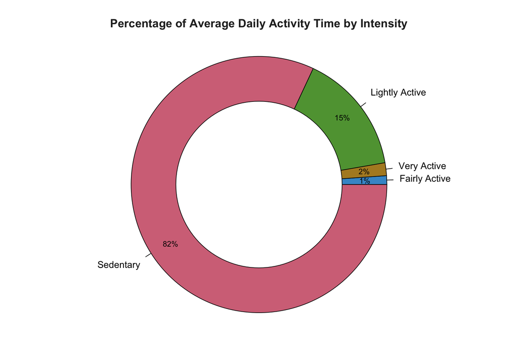

3. Consumers typically spent about 6.5 - 8.3 hours asleep each day and spent only a small amount of time in bed when they weren’t sleeping (typically 0 - 45 minutes).

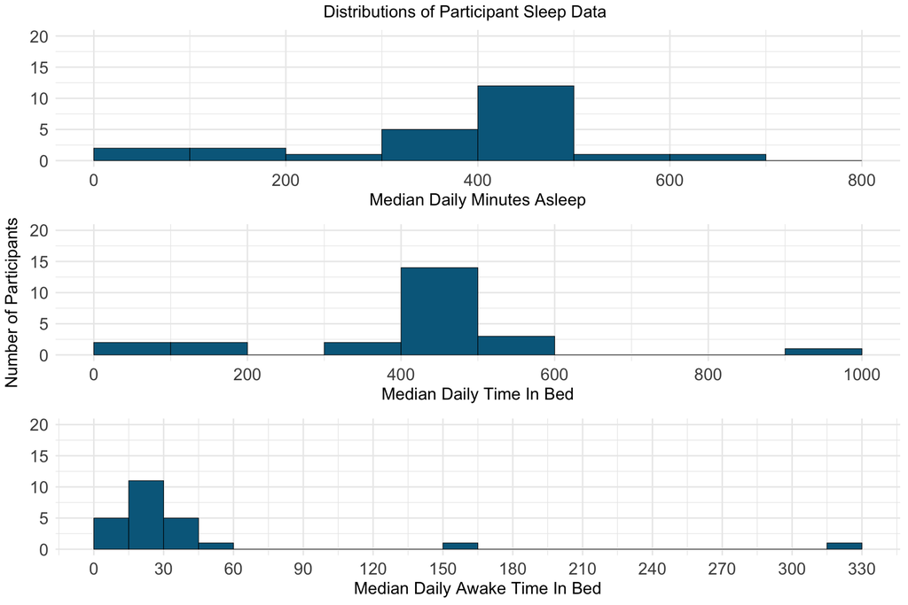

### Recommendations:

Bellabeat can leverage these insights to improve their marketing strategy for their Leaf and Time products as follows:

1. Run ads which market these products as activity tracking devices, but incorporate a social media aspect to the app which allows users to share their activity levels with friends.
2. Run additional ads which highlight sleep and weight tracking features of the products in key locations such as doctors offices or gyms. Additionally, run these ads online and target them to users with online presence indicating interest in weight loss/gain, insomnia, or sleep hygiene.
3. Create ads which include content targeted towards highly active people to encourage this demographic to purchase these products.
4. Create ads which highlight the utility of these products for ensuring a full night of sleep and run them on social media and digital entertainment platforms which consumers are likely to be using when they are in bed before falling asleep.

# **Full Documentation of Project Code**

### Data Loading

```r
# Import libraries
library(tidyverse)
library(janitor) # For get_dupes()
library(gridExtra) # For grid.arrange()
# The PieChart function from the lessR package will be used but not loaded
# outright due to conflicts with tidyverse packages
```

```r
# Read in data
# Specify file paths for each batch of data
path_1 <- './Data_3.12.16-4.11.16'
path_2 <- './Data_4.12.16-5.12.16'

# Combine paths into vector
paths <- c(path_1, path_2)

# Specify file names for each file type
activity_file <- '/dailyActivity_merged.csv'
weight_file <- '/weightLogInfo_merged.csv'
sleep_file <- '/sleepDay_merged.csv'

# Combine file names into vector
files <- c(activity_file, weight_file)

# Read in activity and weight data from each path
for (file in files) {
  # Set data frame name for activity data
  if (file == activity_file) {
    name <- 'activity_data'
  }

  # Set data frame name for weight data
  else if (file == weight_file) {
    name <- 'weight_data'
  }

  # Read in data as df
  df <- read_csv(c(paste(path_1,
                         file,
                         sep = ""),
                   paste(path_2,
                         file,
                         sep = "")))

  # Rename df using predetermined names
  assign(name, df)

  # Drop unused df
  rm(df)
}

# Read in sleep data
# Data present from second path only
sleep_data <- read_csv(paste(path_2,
                             sleep_file,
                             sep = ''))
```

### Data Cleaning and Validation

Because these are time series data, I first calculate the total number of days in the data collection period.

```r
# Calculate total days in the data set
start_date <- as_date('2016-03-12')
end_date <- as_date('2016-05-12')
end_date - start_date + 1 # Add 1 day to include both start and end date
```

```
## Time difference of 62 days
```

#### Activity Data

To clean and validate the activity data, I check for the following issues…

Invalid data types:

```r
glimpse(activity_data)
```

```
## Rows: 1,397
## Columns: 15
## $ Id                       <dbl> 1503960366, 1503960366, 1503960366, 150396036…
## $ ActivityDate             <chr> "3/25/2016", "3/26/2016", "3/27/2016", "3/28/…
## $ TotalSteps               <dbl> 11004, 17609, 12736, 13231, 12041, 10970, 122…
## $ TotalDistance            <dbl> 7.11, 11.55, 8.53, 8.93, 7.85, 7.16, 7.86, 7.…
## $ TrackerDistance          <dbl> 7.11, 11.55, 8.53, 8.93, 7.85, 7.16, 7.86, 7.…
## $ LoggedActivitiesDistance <dbl> 0, 0, 0, 0, 0, 0, 0, 0, 0, 0, 0, 0, 0, 0, 0, …
## $ VeryActiveDistance       <dbl> 2.57, 6.92, 4.66, 3.19, 2.16, 2.36, 2.29, 3.3…
## $ ModeratelyActiveDistance <dbl> 0.46, 0.73, 0.16, 0.79, 1.09, 0.51, 0.49, 0.8…
## $ LightActiveDistance      <dbl> 4.07, 3.91, 3.71, 4.95, 4.61, 4.29, 5.04, 3.6…
## $ SedentaryActiveDistance  <dbl> 0.00, 0.00, 0.00, 0.00, 0.00, 0.00, 0.00, 0.0…
## $ VeryActiveMinutes        <dbl> 33, 89, 56, 39, 28, 30, 33, 47, 40, 15, 43, 3…
## $ FairlyActiveMinutes      <dbl> 12, 17, 5, 20, 28, 13, 12, 21, 11, 30, 18, 18…
## $ LightlyActiveMinutes     <dbl> 205, 274, 268, 224, 243, 223, 239, 200, 244, …
## $ SedentaryMinutes         <dbl> 804, 588, 605, 1080, 763, 1174, 820, 866, 636…
## $ Calories                 <dbl> 1819, 2154, 1944, 1932, 1886, 1820, 1889, 186…
```

```r
# ActivityDate is character but should be date
# Id is numeric but should be factor
```

Missing data:

```r
activity_data %>%
  map(c(is.na, sum))
```

```
## $Id
## [1] 0
##
## $ActivityDate
## [1] 0
##
## $TotalSteps
## [1] 0
##
## $TotalDistance
## [1] 0
##
## $TrackerDistance
## [1] 0
##
## $LoggedActivitiesDistance
## [1] 0
##
## $VeryActiveDistance
## [1] 0
##
## $ModeratelyActiveDistance
## [1] 0
##
## $LightActiveDistance
## [1] 0
##
## $SedentaryActiveDistance
## [1] 0
##
## $VeryActiveMinutes
## [1] 0
##
## $FairlyActiveMinutes
## [1] 0
##
## $LightlyActiveMinutes
## [1] 0
##
## $SedentaryMinutes
## [1] 0
##
## $Calories
## [1] 0
```

```r
# No missing data in any variable
```

Duplicated data:

```r
activity_data %>%
  get_dupes()
```

```
## # A tibble: 0 × 16
## # … with 16 variables: Id <dbl>, ActivityDate <chr>, TotalSteps <dbl>,
## #   TotalDistance <dbl>, TrackerDistance <dbl>, LoggedActivitiesDistance <dbl>,
## #   VeryActiveDistance <dbl>, ModeratelyActiveDistance <dbl>,
## #   LightActiveDistance <dbl>, SedentaryActiveDistance <dbl>,
## #   VeryActiveMinutes <dbl>, FairlyActiveMinutes <dbl>,
## #   LightlyActiveMinutes <dbl>, SedentaryMinutes <dbl>, Calories <dbl>,
## #   dupe_count <int>
```

```r
# There are no duplicated records
```

Dates that are out of the data collection range:

```r
activity_data %>%
  select(ActivityDate) %>%
  mutate(ActivityDate = mdy(ActivityDate)) %>%
  table()
```

```
## ActivityDate
## 2016-03-12 2016-03-13 2016-03-14 2016-03-15 2016-03-16 2016-03-17 2016-03-18
##          2          2          2          2          2          2          2
## 2016-03-19 2016-03-20 2016-03-21 2016-03-22 2016-03-23 2016-03-24 2016-03-25
##          2          2          2          2          2          2          4
## 2016-03-26 2016-03-27 2016-03-28 2016-03-29 2016-03-30 2016-03-31 2016-04-01
##          4          4          4         10         11         11         34
## 2016-04-02 2016-04-03 2016-04-04 2016-04-05 2016-04-06 2016-04-07 2016-04-08
##         35         35         35         35         33         33         33
## 2016-04-09 2016-04-10 2016-04-11 2016-04-12 2016-04-13 2016-04-14 2016-04-15
##         32         29         25         57         33         33         33
## 2016-04-16 2016-04-17 2016-04-18 2016-04-19 2016-04-20 2016-04-21 2016-04-22
##         32         32         32         32         32         32         32
## 2016-04-23 2016-04-24 2016-04-25 2016-04-26 2016-04-27 2016-04-28 2016-04-29
##         32         32         32         32         32         32         32
## 2016-04-30 2016-05-01 2016-05-02 2016-05-03 2016-05-04 2016-05-05 2016-05-06
##         31         30         29         29         29         29         29
## 2016-05-07 2016-05-08 2016-05-09 2016-05-10 2016-05-11 2016-05-12
##         29         27         27         26         24         21
```

```r
# No out of range date data
# Confirms data not recorded for all participants each day
# Some days include >1 activity for each participant
```

Numeric data that is out of range or unexpected:

```r
activity_data %>%
  select(-c(Id, ActivityDate)) %>%
  summary()
```

```
##    TotalSteps    TotalDistance    TrackerDistance  LoggedActivitiesDistance
##  Min.   :    0   Min.   : 0.000   Min.   : 0.000   Min.   :0.0000
##  1st Qu.: 3146   1st Qu.: 2.170   1st Qu.: 2.160   1st Qu.:0.0000
##  Median : 6999   Median : 4.950   Median : 4.950   Median :0.0000
##  Mean   : 7281   Mean   : 5.219   Mean   : 5.192   Mean   :0.1315
##  3rd Qu.:10544   3rd Qu.: 7.500   3rd Qu.: 7.480   3rd Qu.:0.0000
##  Max.   :36019   Max.   :28.030   Max.   :28.030   Max.   :6.7271
##  VeryActiveDistance ModeratelyActiveDistance LightActiveDistance
##  Min.   : 0.000     Min.   :0.0000           Min.   : 0.000
##  1st Qu.: 0.000     1st Qu.:0.0000           1st Qu.: 1.610
##  Median : 0.100     Median :0.2000           Median : 3.240
##  Mean   : 1.397     Mean   :0.5385           Mean   : 3.193
##  3rd Qu.: 1.830     3rd Qu.:0.7700           3rd Qu.: 4.690
##  Max.   :21.920     Max.   :6.4800           Max.   :12.510
##  SedentaryActiveDistance VeryActiveMinutes FairlyActiveMinutes
##  Min.   :0.000000        Min.   :  0.00    Min.   :  0.0
##  1st Qu.:0.000000        1st Qu.:  0.00    1st Qu.:  0.0
##  Median :0.000000        Median :  2.00    Median :  6.0
##  Mean   :0.001704        Mean   : 19.68    Mean   : 13.4
##  3rd Qu.:0.000000        3rd Qu.: 30.00    3rd Qu.: 18.0
##  Max.   :0.110000        Max.   :210.00    Max.   :660.0
##  LightlyActiveMinutes SedentaryMinutes    Calories
##  Min.   :  0.0        Min.   :   0.0   Min.   :   0
##  1st Qu.:111.0        1st Qu.: 729.0   1st Qu.:1799
##  Median :195.0        Median :1057.0   Median :2114
##  Mean   :185.4        Mean   : 992.5   Mean   :2266
##  3rd Qu.:262.0        3rd Qu.:1244.0   3rd Qu.:2770
##  Max.   :720.0        Max.   :1440.0   Max.   :4900
```

```r
# All numeric data is in acceptable range
```

Composite variables that do not equal the sum of their parts:

```r
# Check if sum of high, moderate, light, and sedentary distance values equal total distance
activity_data %>%
  mutate(DistanceSum = VeryActiveDistance +
                       ModeratelyActiveDistance +
                       LightActiveDistance +
                       SedentaryActiveDistance) %>%
  select(TotalDistance, DistanceSum)
```

```
## # A tibble: 1,397 × 2
##    TotalDistance DistanceSum
##            <dbl>       <dbl>
##  1          7.11        7.10
##  2         11.6        11.6
##  3          8.53        8.53
##  4          8.93        8.93
##  5          7.85        7.86
##  6          7.16        7.16
##  7          7.86        7.82
##  8          7.87        7.79
##  9          7.25        7.19
## 10          6.37        6.37
## # … with 1,387 more rows
```

```r
# There are some discrepancies between sum of distance categories and total distance
# Discrepancy cannot be explained without further access to metadata
```

I also want to know how complete the data is, so I check…

The completeness of the sample size:

```r
activity_data %>%
  select(Id) %>%
  summarize(n = n_distinct(Id))
```

```
## # A tibble: 1 × 1
##       n
##   <int>
## 1    35
```

```r
# Data from all 35 participants
```

The number of days in the time series:

```r
activity_data %>%
  select(ActivityDate) %>%
  summarize(days = n_distinct(ActivityDate))
```

```
## # A tibble: 1 × 1
##    days
##   <int>
## 1    62
```

```r
# Data from 62 days
```

The number of observations from each participant:

```r
activity_data %>%
  select(Id) %>%
  group_by(Id) %>%
  table()
```

```
## Id
## 1503960366 1624580081 1644430081 1844505072 1927972279 2022484408 2026352035
##         50         50         40         43         43         43         43
## 2320127002 2347167796 2873212765 2891001357 3372868164 3977333714 4020332650
##         43         33         43          8         30         42         63
## 4057192912 4319703577 4388161847 4445114986 4558609924 4702921684 5553957443
##         36         43         39         46         43         46         43
## 5577150313 6117666160 6290855005 6391747486 6775888955 6962181067 7007744171
##         41         38         39          9         35         45         38
## 7086361926 8053475328 8253242879 8378563200 8583815059 8792009665 8877689391
##         43         42         31         43         39         41         43
```

```r
# Id 4020332650 had data for more days than the collection period
# Id 2891001357 and 6391747486 had minimal data (only 8 and 9 activities)
# Suggests that more than one activity may be observed per day and that not all participants had activity data each day
```

Finally, I apply the necessary corrections to clean the data:

```r
# Convert ActivityDate into date format and rename, and order by Id and Date
activity_data_clean <- activity_data %>%
  mutate(ActivityDate = mdy(ActivityDate)) %>%
  rename(Date = ActivityDate) %>%
  arrange(Id, Date)
```

#### Weight Data

The process for cleaning and validating the weight data is very similar. Again, I check for the following possible issues…

Invalid data types:

```r
glimpse(weight_data)
```

```
## Rows: 100
## Columns: 8
## $ Id             <dbl> 1503960366, 1927972279, 2347167796, 2873212765, 2873212…
## $ Date           <chr> "4/5/2016 11:59:59 PM", "4/10/2016 6:33:26 PM", "4/3/20…
## $ WeightKg       <dbl> 53.3, 129.6, 63.4, 56.7, 57.2, 88.4, 92.4, 69.4, 99.7, …
## $ WeightPounds   <dbl> 117.5064, 285.7191, 139.7731, 125.0021, 126.1044, 194.8…
## $ Fat            <dbl> 22, NA, 10, NA, NA, NA, NA, NA, NA, NA, NA, NA, NA, NA,…
## $ BMI            <dbl> 22.97, 46.17, 24.77, 21.45, 21.65, 25.03, 35.01, 27.14,…
## $ IsManualReport <lgl> TRUE, FALSE, TRUE, TRUE, TRUE, TRUE, TRUE, TRUE, TRUE, …
## $ LogId          <dbl> 1.459901e+12, 1.460313e+12, 1.459728e+12, 1.459987e+12,…
```

```r
# Date is character but should be date type
# Date includes times but should not
# Id is numeric but should be factor
```

Missing data:

```r
weight_data %>%
  map(c(is.na, sum))
```

```
## $Id
## [1] 0
##
## $Date
## [1] 0
##
## $WeightKg
## [1] 0
##
## $WeightPounds
## [1] 0
##
## $Fat
## [1] 96
##
## $BMI
## [1] 0
##
## $IsManualReport
## [1] 0
##
## $LogId
## [1] 0
```

```r
# Missing data observed for 96 records of the Fat variable
```

Duplicated data:

```r
weight_data %>%
  get_dupes()
```

```
## # A tibble: 4 × 9
##           Id Date            Weigh…¹ Weigh…²   Fat   BMI IsMan…³   LogId dupe_…⁴
##        <dbl> <chr>             <dbl>   <dbl> <dbl> <dbl> <lgl>     <dbl>   <int>
## 1 6962181067 4/12/2016 11:5…    62.5    138.    NA  24.4 TRUE    1.46e12       2
## 2 6962181067 4/12/2016 11:5…    62.5    138.    NA  24.4 TRUE    1.46e12       2
## 3 8877689391 4/12/2016 6:47…    85.8    189.    NA  25.7 FALSE   1.46e12       2
## 4 8877689391 4/12/2016 6:47…    85.8    189.    NA  25.7 FALSE   1.46e12       2
## # … with abbreviated variable names ¹WeightKg, ²WeightPounds, ³IsManualReport,
## #   ⁴dupe_count
```

```r
# There are two duplicated records
```

Out of range dates:

```r
weight_data %>%
  select(Date) %>%
  mutate(Date = date(mdy_hms(Date))) %>%
  table()
```

```
## Date
## 2016-03-30 2016-03-31 2016-04-01 2016-04-02 2016-04-03 2016-04-04 2016-04-05
##          2          1          2          1          2          3          4
## 2016-04-06 2016-04-07 2016-04-08 2016-04-09 2016-04-10 2016-04-11 2016-04-12
##          3          4          3          2          2          2          4
## 2016-04-13 2016-04-14 2016-04-15 2016-04-16 2016-04-17 2016-04-18 2016-04-19
##          3          2          1          2          3          3          2
## 2016-04-20 2016-04-21 2016-04-22 2016-04-23 2016-04-24 2016-04-25 2016-04-26
##          2          3          1          2          2          3          1
## 2016-04-27 2016-04-28 2016-04-29 2016-04-30 2016-05-01 2016-05-02 2016-05-03
##          2          2          2          2          3          3          3
## 2016-05-04 2016-05-05 2016-05-06 2016-05-07 2016-05-08 2016-05-09 2016-05-10
##          3          1          2          1          2          3          1
## 2016-05-11 2016-05-12
##          2          3
```

```r
# No out of range date data
# Data begins on 3/30 and at least 1 participant tracks data each day from that point on
```

Out of range or invalid numeric data:

```r
weight_data %>%
  select(WeightKg, WeightPounds, Fat, BMI) %>%
  summary()
```

```
##     WeightKg      WeightPounds        Fat             BMI
##  Min.   : 52.6   Min.   :116.0   Min.   :10.00   Min.   :21.45
##  1st Qu.: 61.5   1st Qu.:135.6   1st Qu.:19.00   1st Qu.:24.00
##  Median : 62.5   Median :137.8   Median :22.00   Median :24.39
##  Mean   : 72.5   Mean   :159.8   Mean   :19.75   Mean   :25.37
##  3rd Qu.: 85.3   3rd Qu.:188.1   3rd Qu.:22.75   3rd Qu.:25.59
##  Max.   :133.5   Max.   :294.3   Max.   :25.00   Max.   :47.54
##                                  NA's   :96
```

```r
# All data is in acceptable range
```

And again, I check for completeness of the data by identifying the number of participants with data:

```r
weight_data %>%
  select(Id) %>%
  summarize(n = n_distinct(Id))
```

```
## # A tibble: 1 × 1
##       n
##   <int>
## 1    13
```

```r
# Data from only 13 participants
```

The number of days in the data set:

```r
weight_data %>%
  select(Date) %>%
  mutate(Date = date(mdy_hms(Date))) %>%
  summarize(days = n_distinct(Date))
```

```
## # A tibble: 1 × 1
##    days
##   <int>
## 1    44
```

```r
# Data from only 44 days
```

And the number of records for each participant:

```r
weight_data %>%
  select(Id) %>%
  group_by(Id) %>%
  table()
```

```
## Id
## 1503960366 1927972279 2347167796 2873212765 2891001357 4319703577 4445114986
##          3          2          1          4          1          2          1
## 4558609924 4702921684 5577150313 6962181067 8253242879 8877689391
##          6          1          1         44          1         33
```

```r
# Most data comes from two participants
# 6962181067 recorded 44 data points and 8877689391 recorded 33 datapoints
```

Now, I apply the necessary changes to clean the weight data:

```r
# Convert Date to datetime format and separate, drop duplicates, and arrange by Id and Date
weight_data_clean <- weight_data %>%
  separate_wider_delim(
    Date,
    delim = " ",
    names = c('Date', 'Time'),
    too_many = 'merge'
  ) %>%
  mutate(Date = mdy(Date)) %>%
  mutate(Time = hms(Time)) %>%
  distinct() %>%
  arrange(Id, Date)
```